# DP3 Spacecraft Final code

### Importing all necessary packages

```python
import sympy as sym
import numpy as np
from IPython.display import display, Markdown
import ae353_spacecraft_design as design
from scipy.optimize import minimize
from sympy import *
import control
import time
import matplotlib.pyplot as plt
import ae353_spacecraft_simulate
import scipy

# Suppress the use of scientific notation when printing small numbers
np.set_printoptions(suppress=True)
```

```
pybullet build time: Sep  3 2024 12:57:17
```

### Creating the visulation tab in your browser to view simulation

```python
simulator = ae353_spacecraft_simulate.Simulator(
    display=False,
    seed=None,
)
```

```
argv[0]=
```

### Create spacecraft

```python
# Create the visualizer
vis = design.create_visualizer()

# Show the visualizer in this notebook
vis.jupyter_cell()
```

```
You can open the visualizer by visiting the following URL:
http://127.0.0.1:7024/static/
```

[interactive chart not shown]

Specifying the location of four reaction wheels in terms of their right ascension $\alpha$ and declination $\beta$. The number of wheels cannot change for this design project.

```python
# Defining reaction wheel locations
wheels = [
    {'alpha': np.pi, 'delta': np.pi /6},
    {'alpha':  np.pi / 3, 'delta': np.pi/6},
    {'alpha': -np.pi /3 , 'delta': np.pi/6},
    {'alpha': 0, 'delta': -np.pi/2},
]
design.show_wheels(vis, wheels) # Show wheels in visualizer

# Create a model of the spacecraft in URDF format
m, J = design.create_spacecraft(wheels)
display(Markdown(
       r'$$'
    + fr'm = {sym.latex(np.round(m, decimals=2))}'
    +  r' \qquad\qquad '
    + fr'J = {sym.latex(sym.Matrix(J.round(decimals=2)))}'
    +  r'$$'
))
```

$$m = 19.0 \qquad\qquad J = \left[\begin{matrix}23.37 & 0.0 & 0.0\\0.0 & 23.37 & 0.0\\0.0 & 0.0 & 20.08\end{matrix}\right]$$

### Create stars

Creating stars for star tracking sensor model. The star tracker is a camera that measures the postion in an image of each star (yellow) in its field of view.

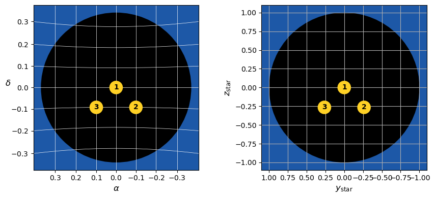

```python
# Defining star location
stars = [
    {'alpha':  0.00, 'delta':  0.00},        # Alpha = right ascension (rad)
    {'alpha':  -0.10, 'delta':  -0.10},      # Beta = declination (rad)
    {'alpha':  0.10, 'delta':  -0.10}
]
design.show_stars(stars)                     # Create a file with location of stars
```

## Create dynamic and sensor model

Deriving the equations of motion and devolping the sensor model.

```python
# Define yaw, pitch, roll angles
psi, theta, phi = sym.symbols('psi, theta, phi')

# Define alpha and delta symbols
alpha, delta = sym.symbols('alpha, delta')

# Define angular velocities
w_x, w_y, w_z = sym.symbols('w_x, w_y, w_z')

# Define torques
tau_1, tau_2, tau_3, tau_4 = sym.symbols('tau_1, tau_2, tau_3, tau_4')

# Compute resultant torques
T1 = - tau_1 * sym.Matrix(wheels[0]['xyz']) / np.linalg.norm(wheels[0]['xyz'])
T2 = - tau_2 * sym.Matrix(wheels[1]['xyz']) / np.linalg.norm(wheels[1]['xyz'])
T3 = - tau_3 * sym.Matrix(wheels[2]['xyz']) / np.linalg.norm(wheels[2]['xyz'])
T4 = - tau_4 * sym.Matrix(wheels[3]['xyz']) / np.linalg.norm(wheels[3]['xyz'])
T = sym.nsimplify(T1 + T2 + T3 + T4)

# Define rotation matrices
Rz = sym.Matrix([[sym.cos(psi), -sym.sin(psi), 0], [sym.sin(psi), sym.cos(psi), 0], [0, 0, 1]])
Ry = sym.Matrix([[sym.cos(theta), 0, sym.sin(theta)], [0, 1, 0], [-sym.sin(theta), 0, sym.cos(theta)]])
Rx = sym.Matrix([[1, 0, 0], [0, sym.cos(phi), -sym.sin(phi)], [0, sym.sin(phi), sym.cos(phi)]])

# Define the transformation from angular velocity to angular rates
ex = sym.Matrix([[1], [0], [0]])
ey = sym.Matrix([[0], [1], [0]])
ez = sym.Matrix([[0], [0], [1]])
M = sym.simplify(sym.Matrix.hstack((Ry @ Rx).T @ ez, Rx.T @ ey, ex).inv(), full=True)

# Define euler's equations
Jx, Jy, Jz = [sym.nsimplify(j) for j in np.diag(J)]
euler = sym.Matrix([[(1 / Jx) * (T[0] + (Jy - Jz) * w_y * w_z)],
                    [(1 / Jy) * (T[1] + (Jz - Jx) * w_z * w_x)],
                    [(1 / Jz) * (T[2] + (Jx - Jy) * w_x * w_y)]])

# Define equations of motion
f = sym.simplify(sym.Matrix.vstack(M * sym.Matrix([[w_x], [w_y], [w_z]]), euler), full=True)

F_num = lambdify([psi, theta, phi, w_x, w_y, w_z, tau_1, tau_2, tau_3, tau_4], [f])

f_num_for_minimize  = lambda x: np.linalg.norm(np.array( F_num(*x) ). flatten())**2

# Position of star in space frame
p_star_in_space = sym.Matrix([[sym.cos(alpha) * sym.cos(delta)],
                              [sym.sin(alpha) * sym.cos(delta)],
                              [sym.sin(delta)]])

# Orientation of body frame in space frame
R_body_in_space = Rz * Ry * Rx

# Position of star in body frame (assuming origin of body and space frames are the same)
p_star_in_body = R_body_in_space.T * p_star_in_space

# Position of star in image frame
r = sym.nsimplify(design.scope_radius)
p_star_in_image = (1 / r) * sym.Matrix([[p_star_in_body[1] / p_star_in_body[0]],
                                        [p_star_in_body[2] / p_star_in_body[0]]])

# Sensor model for each star
g = sym.simplify(p_star_in_image, full=True)

# Define alpha and delta symbols
alpha, delta = sym.symbols('alpha delta')

# Compute symbolic sensor model once
g = sym.simplify(p_star_in_image, full=True)

# Initialize list to hold g values
g_entries = []

# Loop through each star and substitute alpha, delta
for star in stars:
    g_star = g.subs({alpha: star['alpha'], delta: star['delta']})
    g_entries.extend(g_star)  # Flatten and append both components

# Create 6x1 column matrix
g_matrix = sym.Matrix(g_entries)


g_matrix
```

$\displaystyle \left[\begin{matrix}\frac{21 \left(\sin{\left(\phi \right)} \sin{\left(\theta \right)} \cos{\left(\psi \right)} - \sin{\left(\psi \right)} \cos{\left(\phi \right)}\right)}{8 \cos{\left(\psi \right)} \cos{\left(\theta \right)}}\\\frac{21 \left(\sin{\left(\phi \right)} \sin{\left(\psi \right)} + \sin{\left(\theta \right)} \cos{\left(\phi \right)} \cos{\left(\psi \right)}\right)}{8 \cos{\left(\psi \right)} \cos{\left(\theta \right)}}\\\frac{21 \left(0.995004165278026 \sin{\left(\phi \right)} \sin{\left(\theta \right)} \cos{\left(\psi + 0.1 \right)} - 0.0998334166468282 \sin{\left(\phi \right)} \cos{\left(\theta \right)} - 0.995004165278026 \sin{\left(\psi + 0.1 \right)} \cos{\left(\phi \right)}\right)}{8 \left(0.0998334166468282 \sin{\left(\theta \right)} + 0.995004165278026 \cos{\left(\theta \right)} \cos{\left(\psi + 0.1 \right)}\right)}\\\frac{21 \left(0.995004165278026 \sin{\left(\phi \right)} \sin{\left(\psi + 0.1 \right)} + 0.995004165278026 \sin{\left(\theta \right)} \cos{\left(\phi \right)} \cos{\left(\psi + 0.1 \right)} - 0.0998334166468282 \cos{\left(\phi \right)} \cos{\left(\theta \right)}\right)}{8 \left(0.0998334166468282 \sin{\left(\theta \right)} + 0.995004165278026 \cos{\left(\theta \right)} \cos{\left(\psi + 0.1 \right)}\right)}\\\frac{21 \left(0.995004165278026 \sin{\left(\phi \right)} \sin{\left(\theta \right)} \cos{\left(\psi - 0.1 \right)} - 0.0998334166468282 \sin{\left(\phi \right)} \cos{\left(\theta \right)} - 0.995004165278026 \sin{\left(\psi - 0.1 \right)} \cos{\left(\phi \right)}\right)}{8 \left(0.0998334166468282 \sin{\left(\theta \right)} + 0.995004165278026 \cos{\left(\theta \right)} \cos{\left(\psi - 0.1 \right)}\right)}\\\frac{21 \left(0.995004165278026 \sin{\left(\phi \right)} \sin{\left(\psi - 0.1 \right)} + 0.995004165278026 \sin{\left(\theta \right)} \cos{\left(\phi \right)} \cos{\left(\psi - 0.1 \right)} - 0.0998334166468282 \cos{\left(\phi \right)} \cos{\left(\theta \right)}\right)}{8 \left(0.0998334166468282 \sin{\left(\theta \right)} + 0.995004165278026 \cos{\left(\theta \right)} \cos{\left(\psi - 0.1 \right)}\right)}\end{matrix}\right]$

## State space model

Constructing A, B, C, D, W, and Wo matricies.

```python
# Minimize the cost function to find a equilibrium point at some inital guess
# Inital guess for equilibrium point
x0 = [0. , # Guess at psi
      0. , # Guess at theta
      0. , # Guess at phi
      0. , # Guess at w_x
      0. , # Guess at w_y
      0. , # Guess at w_z
      0. , # Guess at tau_1
      0. , # Guess at tau_2
      0. , # Guess at tau_3
      0. ] # Guess at tau_4

sol = minimize(f_num_for_minimize, x0, tol=1e-6) # Find minimum

# Show solution
psi_e   = sol.x[0]
theta_e = sol.x[1]
phi_e   = sol.x[2]
w_xe    = sol.x[3]
w_ye    = sol.x[4]
w_ze    = sol.x[5]
tau_1e  = sol.x[6]
tau_2e  = sol.x[7]
tau_3e  = sol.x[8]
tau_4e  = sol.x[9]

# Taking the jacobian to construct A and B matrix
A_sym = f.jacobian([psi, theta, phi, w_x, w_y, w_z])
B_sym = f.jacobian([tau_1, tau_2, tau_3, tau_4])

# Defining lambda function to convert A, B from symbolic to numeric
A_num = sym.lambdify([psi, theta, phi, w_x, w_y, w_z, tau_1, tau_2, tau_3, tau_4], A_sym)
B_num = sym.lambdify([psi, theta, phi, w_x, w_y, w_z, tau_1, tau_2, tau_3, tau_4], B_sym)

A = A_num(psi_e, theta_e, phi_e, w_xe, w_ye, w_ze, tau_1e, tau_2e, tau_3e, tau_4e)
B = B_num(psi_e, theta_e, phi_e, w_xe, w_ye, w_ze, tau_1e, tau_2e, tau_3e, tau_4e)

n = A.shape[0]

# Computing W matrix to determine controllability
W = B
for i in range(1, n):
    col = np.linalg.matrix_power(A, i) @ B
    W = np.block([W, col])
l = np.linalg.matrix_rank(W) # To be controllable, W must be full rank

# Computing C and D for sensor model
# Converting C, D from symbolic to numeric
C_num = sym.lambdify([psi, theta, phi, w_x, w_y, w_z, tau_1, tau_2, tau_3, tau_4],g_matrix.jacobian([psi, theta, phi, w_x, w_y, w_z]))
D_num = sym.lambdify([psi, theta, phi, w_x, w_y, w_z, tau_1, tau_2, tau_3, tau_4],g_matrix.jacobian([tau_1, tau_2, tau_3, tau_4]))

# Inputing equilibrium values
C = C_num(psi_e, theta_e, phi_e, w_xe, w_ye, w_ze, tau_1e, tau_2e, tau_3e, tau_4e)
D = D_num(psi_e, theta_e, phi_e, w_xe, w_ye, w_ze, tau_1e, tau_2e, tau_3e, tau_4e)

sym.Matrix(C)
sym.Matrix(D)

# Computing Wo matrix to determine controllability
n = A.shape[0]
Wo = C.T
for i in range(1, n):
    col = np.linalg.matrix_power(A.T, i) @ C.T
    Wo = np.block([Wo, col])
Wo = Wo.T
rank_o= np.linalg.matrix_rank(Wo) # To be controllable, Wo must be full rank
```

Implementing LQR for our state space model. This function takes A,B,Q,R and calculates a gain matrix K.

```python
Q = np.diag([1000.,1000.,1000.,100.,100.,100.]) # Weights of importance for our state vector
R = np.diag([1., 1., 1., 1.])                   # Pentalizes excessive control effort, high Q/R = more agressive
K, _, _ = control.lqr(A, B, Q, R)               # Produces a optimal controller
F_matrix = (A - B@K)
s = np.linalg.eigvals(F_matrix)                 # Finding eigenvalues
```

Implementing LQR for our sensor model. This function takes A, C, Ro, Qo and calculates a gain matrix L.

```python
Qo = np.diag([1.,1.,1.,1.,1.,1.])               # Weights of importance for our sensor model
Ro = np.diag([1.,1.,1.,1.,1.,1.])               # Pentalizes excessive control effort, high Q/R = more agressive
l, _, _ = control.lqr(A.T, C.T, np.linalg.inv(Ro), np.linalg.inv(Qo)) # Produces a optimal observer
L = l.T
O_matrix = (A - L@C)
s = np.linalg.eigvals(O_matrix)                 # Finding eigenvalues
```

Here we pull the star locations as the sensor sees them in order to construct y in the controller.

```python
star_point = []
for star in stars:
    y,z = design.project_star(star['alpha'], star['delta'], design.scope_radius)
    star_point.append(y)
    star_point.append(z)
b = np.array(star_point)
```

# Simulation of spacecraft with reaction wheels and star tracker

Creating an instance of the `Simulator` class, which is an interface to the [pybullet](http://pybullet.org) simulation engine.

Here we define a controller that maps sensor measurements to actuator commands. This function will be called 25 times per second (i.e., at 25 Hz) by the simulator.

```python
simulator.camera_sideview()
# Define a controller that implements linear state feedback
class Controller:
    def __init__(self, psi_e, theta_e, phi_e, w_xe, w_ye, w_ze, tau_1e, tau_2e, tau_3e, tau_4e, A, B, C, L, K, b):

        # Initalize equilibrium values for oreintation and angular velocity
        self.psi_e = psi_e
        self.theta_e = theta_e
        self.phi_e = phi_e
        self.w_xe = w_xe
        self.w_ye = w_ye
        self.w_ze = w_ze

        # Initalize equilibrium values for input torques
        self.tau_1e = tau_1e
        self.tau_2e = tau_2e
        self.tau_3e = tau_3e
        self.tau_4e = tau_4e

        # System matricies
        self.A = A
        self.B = B
        self.C = C
        # Feedback and observer gain matrices
        self.K = K # State feedback gain
        self.L = L # Observer design

        self.b = b

    def reset(self):
        # Reset observer state esitmate to zero
        self.xhat = np.array([0.0, 0.0, 0.0, 0.0, 0.0, 0.0])
        self.xhat_history = {"roll" : [],
                             "pitch" : [],
                             "yaw" : [],
                             "wx" : [],
                             "wy" : [],
                             "wz" : []}


    def run(self, t, star_measurements):

        dt = 0.04  # Time stepping value for x_hat

        # Appending xhat history for error calculation
        self.xhat_history["roll"].append(self.xhat[0])
        self.xhat_history["pitch"].append(self.xhat[1])
        self.xhat_history["yaw"].append(self.xhat[2])
        self.xhat_history["wx"].append(self.xhat[3])
        self.xhat_history["wy"].append(self.xhat[4])
        self.xhat_history["wz"].append(self.xhat[5])

        # Equilibrium input vector
        inputs = np.array([self.tau_1e, self.tau_2e, self.tau_3e, self.tau_4e])

        # State feedback control
        u = -self.K@self.xhat

        new_u = u + inputs

        y = star_measurements - self.b

        # Observer
        self.xhat += (self.A @ self.xhat + self.B @ u - self.L @ (self.C @ self.xhat - y))*dt
        return new_u
```

## Spacecraft simulation and plotting

While the simulator is running, it will terminate when any of the following conditions are met:

- Any star goes out of view of the scope.
- Any reaction wheel has angular velocity exceeding +/- 50 rad/s.
- The maximum time is reached.

Running the simulation once to generate state estimate error plots.

[figure not shown]

```
The space-cat docked.
```

```python
# Create an instance of the controller.
controller = Controller(psi_e, theta_e, phi_e, w_xe, w_ye, w_ze, tau_1e, tau_2e, tau_3e, tau_4e, A, B, C, L, K, b)

simulator.reset(
    initial_conditions=None,
    scope_noise=0.1,        # Standard deviation of each image coordinate of each star tracker measurement
    space_debris=True,      # Whether or not there is space debris
    docking_time=60.        # How long it takes for the space-cat to dock with the spacecraft
)

controller.reset()

data = simulator.run(
    controller,             # Instance of your Controller class
    max_time = 60.0,        # Simulation duration in seconds
    data_filename=None,     # File to which you want data saved
    video_filename=None,    # File to which you want video saved
    print_debug=False,      # Print debug text
)
symbolic_labels = {
    "phi": r"$\phi$",
    "theta": r"$\theta$",
    "psi": r"$\psi$",
}

# Time array
t_vals = np.arange(len(controller.xhat_history["roll"])) * 0.04

# Define state keys
state_keys = ["roll", "pitch", "yaw"]

# Create arrays from xhat and data
xhat_array = np.stack([controller.xhat_history[k] for k in state_keys], axis=1)
x_array = np.stack([data[k] for k in ["phi", "theta", "psi"]], axis=1)

# Equilibrium (assumed zero for normalized deviation unless specified)
x_equil = np.zeros(3)

# Compute error norms
x_error_norm = np.linalg.norm(x_array - x_equil, axis=1)
xhat_error_norm = np.linalg.norm(xhat_array - x_equil, axis=1)

# Normalize each independently
x_error_norm /= np.max(np.abs(x_error_norm))
xhat_error_norm /= np.max(np.abs(xhat_error_norm))

# Plotting
plt.figure(figsize=(12, 6))
plt.plot(t_vals, x_error_norm, '-', linewidth=3, color = 'red', label=r"$\|x - x_{\mathrm{eq}}\|$ (normalized)")
plt.plot(t_vals, xhat_error_norm, '--', linewidth=3,color = 'green', label=r"$\|\hat{x} - x\|$ (normalized)")

# Styling
plt.xlabel("Time (s)", fontsize=18)
plt.ylabel("Normalized Error", fontsize=18)
plt.xticks(fontsize=16)
plt.yticks(fontsize=16)
plt.grid(True)
plt.legend(fontsize=16)
plt.tight_layout()
plt.show()

# Docking result
if simulator.has_docked():
    print("The space-cat docked.")
else:
    print("The space-cat did not dock.")
```

Running the simulation for multiple simulations to generate success vs. failure plots

```
Failed [ 0.0067552  -0.2859049  -0.34175002 -0.29749816  0.19583394 -0.80655822]
Failed [ 0.11220295 -0.02323445 -0.33039122 -0.42778916  0.17293651 -0.35699985]
Succeeded [ 0.26931611  0.20848483 -0.14944982 -0.39595758  0.45088456 -0.32904876]
Succeeded [-0.16290902 -0.10996095 -0.31702312 -0.52312412  0.06238168 -0.26800135]
Succeeded [-0.18628344 -0.23131542 -0.34031619 -0.58156565  0.19657532 -0.63746519]
Succeeded [-0.13738959  0.22418447 -0.28043652 -0.11518797  0.37469223 -0.29454772]
Failed [ 0.0155959   0.18395401 -0.31055218 -0.13015236  0.33121154  0.02500006]
Succeeded [ 0.01608196 -0.00356418 -0.31560761 -0.18633855  0.16990618 -0.07647086]
Failed [-0.01962409  0.12119456 -0.34047282 -0.1176018   0.23795745 -0.26302736]
Succeeded [-0.18519564 -0.06484908 -0.4266982  -0.29146341 -0.08142048 -0.49017066]
Succeeded [ 0.10371715 -0.00499624  0.04477742 -0.24620082  0.36517077 -0.34639907]
Succeeded [-0.20084393  0.1033422  -0.37335475 -0.48815659  0.04828482 -0.18384582]
Failed [ 0.16524885 -0.10839806 -0.2113928  -0.21179375  0.31759313 -0.23371999]
Succeeded [-0.04393235  0.14332116 -0.28863667 -0.2645469   0.21400545 -0.23602694]
Failed [-0.11171799  0.07832246 -0.34405028 -0.16598921  0.07694856 -0.20019744]
Failed [ 0.01386576 -0.05026291 -0.04052898 -0.34389469  0.39393269 -0.51850075]
Succeeded [ 0.38435588 -0.18268671  0.14700756 -0.37979154  0.64494925 -0.23263097]
Succeeded [ 0.15299346  0.07283745 -0.14919449 -0.13515467  0.38154113 -0.33267592]
Succeeded [ 0.07613872 -0.03500442 -0.11038554 -0.32310118  0.39386013 -0.20064353]
Failed [-0.20905614  0.12850035 -0.36449193 -0.12240316  0.17244249 -0.08734778]
Succeeded [-0.00544094 -0.20145219 -0.23910674 -0.4706068   0.41802708 -0.61113973]
Failed [-0.04672289  0.10571729 -0.23718966 -0.24633335  0.24085133 -0.14137613]
Succeeded [-0.20735091  0.16557315 -0.31973646 -0.13747618  0.00829434 -0.24373424]
Failed [-0.2557783   0.164551   -0.31669769 -0.03864281  0.12506448 -0.02893283]
Failed [ 0.27156588 -0.16678198  0.04550968 -0.53430373  0.36675379 -0.39338843]
Succeeded [ 0.12480319  0.17405326 -0.20978924 -0.13209383  0.3312685  -0.11927564]
Failed [ 0.24608041 -0.19864092 -0.17168546 -0.58428582  0.44298809 -0.62361733]
Failed [-0.13576357  0.01051387 -0.50850637 -0.22751567  0.1297196  -0.13681275]
Succeeded [-0.09801527  0.03265081 -0.27424022 -0.51032436  0.23350548 -0.18746789]
Succeeded [ 0.11086904 -0.04865805 -0.17620149 -0.25799748  0.34790127 -0.20789336]
Failed [ 0.21220802 -0.08382452 -0.07458927 -0.22482148  0.29947625 -0.40837313]
Failed [-0.06166844 -0.00864328 -0.16029779 -0.20007465  0.18100497 -0.50044729]
Succeeded [ 0.32564891  0.04244317 -0.06620497 -0.24776012  0.42048256 -0.16691559]
Failed [ 0.35624392 -0.01279433 -0.12865567 -0.21636568  0.5598664  -0.13585059]
Failed [ 0.08279719 -0.04222689 -0.40110358 -0.34555531  0.15013494 -0.23043318]
Succeeded [ 0.11905784 -0.40568466 -0.21916991 -0.46233591  0.3866818  -0.45954084]
Failed [-0.10254288 -0.02496777 -0.28409095 -0.21743318  0.13657561 -0.4331906 ]
Failed [-0.06051234 -0.27721046 -0.24861374 -0.53522764  0.42051556 -0.59199424]
Succeeded [ 0.25248962 -0.19322877 -0.20535025 -0.49841983  0.26855872 -0.67837059]
Failed [-0.04688665 -0.01540724 -0.2460319  -0.4630731   0.30691678 -0.43770816]
```

[output cut: 46 more lines]

```
Failed [-0.13061553  0.00055579 -0.45606561 -0.08755228  0.14566882 -0.16316949]
Succeeded [ 0.11960608  0.12427528 -0.36899279 -0.10293482  0.26199707 -0.25744936]
Failed [ 0.03729564 -0.03267526 -0.49122233 -0.49606586  0.40151702 -0.44019759]
Failed [ 0.1698757   0.27482291 -0.40727837 -0.05699658  0.32014625 -0.0072742 ]
Failed [-0.27309823  0.12271348 -0.53925649 -0.05224343 -0.02421861 -0.39214214]
Failed [-0.02334303 -0.35921313 -0.36493179 -0.44357123  0.15180453 -0.34821209]
Succeeded [ 0.01683455 -0.01771005 -0.2160713  -0.09142274  0.12518669  0.10715961]
Failed [ 0.2810557  -0.00580004 -0.02511842 -0.31089693  0.50713223  0.0255539 ]
Succeeded [ 0.26403515 -0.13116041  0.18601496 -0.54788968  0.4658296  -0.35915604]
Succeeded [ 0.42188229 -0.02173423 -0.18390021 -0.23836581  0.26173235 -0.21960635]
Failed [-0.19904334  0.00831924 -0.26549509 -0.29924657  0.30825694 -0.15897226]
Succeeded [ 0.03261481 -0.15989958 -0.37630547 -0.37479524  0.17006981 -0.52747691]
Succeeded [ 0.0669026  -0.06687785 -0.1486975  -0.19974699  0.24659772 -0.23256312]
Total Cats Saved:
48
```

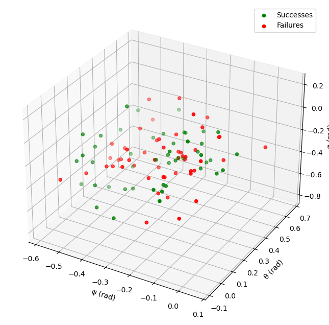

```python
# Get initial sensor measurements before simulation starts
p = simulator.get_sensor_measurements()

# Initialize lists to record results
arrayofsaved = []  # Binary list: 1 if docked, 0 if failed
successes = []     # Stores sensor measurements that led to successful docking
failures = []      # Stores sensor measurements that led to failed docking

# Check if initial state leads to docking success or failure
if simulator.has_docked():
    arrayofsaved.append(1)
    successes.append(p)
else:
    arrayofsaved.append(0)
    failures.append(p)

# Run 99 more trials (for a total of 100)
index = 1
while index < 100:
    # Run the simulation
    data = simulator.run(
        controller,           # Instance of the Controller class
        max_time=60.,         # Run time in seconds
        data_filename=None,   # Data is not being saved to file
        video_filename=None   # Video is not being saved to file
    )

    # Check the docking outcome
    if simulator.has_docked():
        print('Succeeded', p)
        arrayofsaved.append(1)
        successes.append(p)
    else:
        print('Failed', p)
        arrayofsaved.append(0)
        failures.append(p)

    # Prepare for next trial
    index += 1
    simulator.reset()           # Reset the simulation
    controller.reset()          # Reset the controller's internal state
    p = simulator.get_sensor_measurements()  # New sensor reading for next trial

# Print total number of successful dockings
print('Total Cats Saved:')
print(sum(arrayofsaved))

# Convert successes and failures to NumPy arrays for easy slicing
successes = np.array(successes)
failures = np.array(failures)

# Extract psi, theta, phi from the 4th, 5th, and 6th elements of each sample
psi_success = successes[:, 3]
theta_success = successes[:, 4]
phi_success = successes[:, 5]

psi_failure = failures[:, 3]
theta_failure = failures[:, 4]
phi_failure = failures[:, 5]

# 3D Plot: ψ, θ, φ
fig = plt.figure(figsize=(8, 8))
ax = fig.add_subplot(111, projection='3d')
ax.scatter(psi_success, theta_success, phi_success, color='green', label='Successes')
ax.scatter(psi_failure, theta_failure, phi_failure, color='red', label='Failures')
ax.set_xlabel('ψ (rad)')
ax.set_ylabel('θ (rad)')
ax.set_zlabel('φ (rad)')
plt.legend()
plt.show()
```